# Central limit theorem

The [law of large numbers](https://en.wikipedia.org/wiki/Law_of_large_numbers) shows that the average of many samples will approach the expected value as the number of samples goes to infinity:

$$\lim_{n \to \infty} \sum_{i=1}^n \frac{X_i}{n} = E(X).$$

For [independent and identically distributed variables](https://en.wikipedia.org/wiki/Independent_and_identically_distributed_random_variables), the [central limit theorem](https://en.wikipedia.org/wiki/Central_limit_theorem) shows that as your sample size increases, the distribution of averages approaches a [normal distribution](https://en.wikipedia.org/wiki/Normal_distribution).

## Exponential

An exponential distribution can describe events that happen at a constant average rate, independently from each other. It has a density function,

$$f(x) = \lambda e^{- \lambda x}, \text{for} \hspace{0.1cm} x \geq 0.$$

We define our rate parameter ($\lambda$), calculate the theoretical population mean ($\mu$), standard deviation ($\sigma$), and variance ($\sigma^2$):

- $\lambda = 0.2$
- $\mu = \sigma = 1/\lambda = 5$
- $\sigma^2 = 25$

## Simulation

We take $k = 1000$ means of exponential samples each with $n = 50$.

```r
#' n: # number of rexp samples for each mean
#' k: # number of means
generate_means <- function(n, k, lambda) {
  #' collect k means, each with n samples, in an array
  sample_means = NULL
  for (i in 1:k) sample_means = c(sample_means, mean(rexp(n, lambda)))
  means_df <- data.frame(means = sample_means)
  means_df
}
```

```r
df1 <- generate_means(n, k, lambda)
```

Since we are sampling from the `rexp` function, we know the data is independent and identically distributed. A sample histogram shows that the values follow an exponential curve.

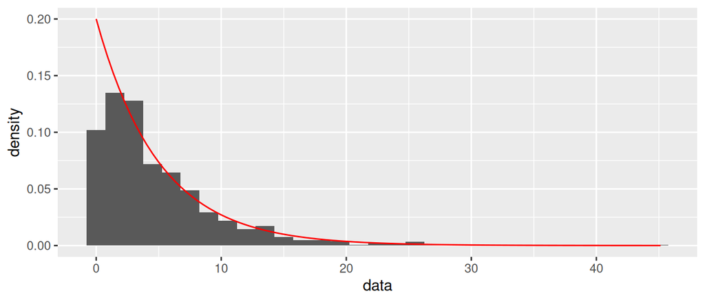

We are interested in the means of these samples, so the central limit theorem applies. The overall mean of our sampled means is $5.024$, close to the theoretical value of $5$ represented by the red line on the boxplot.

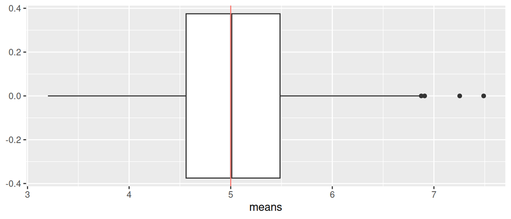

Assuming $n = 50$ is large enough, the distribution of means approaches a normal with mean $\mu$ and variance $\sigma^2/n$, where $\sigma^2$ is the variance of the exponential distribution we were originally sampling from. The variance $\sigma^2/n$ is referred to as the *standard error*, and will be our theoretical variance.

- exponential variance ($\sigma^2$): $25$
- theoretical variance ($\sigma^2/n$): $0.5$
- sample variance: $0.4578683$

While the underlying samples are exponential, the distribution of means looks normal, centered around the theoretical population mean $\mu$, with standard deviation $\sigma/\sqrt{n}$.

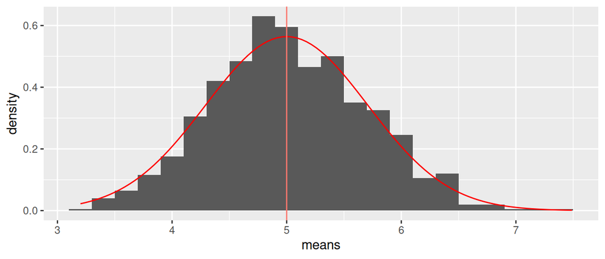

Any individual sample of the exponential distribution can have a mean far from the population mean, as seen for cumulative means with small $k$ on the left. As we average over more sample means, we get closer to the theoretical population mean $\mu = 5$.

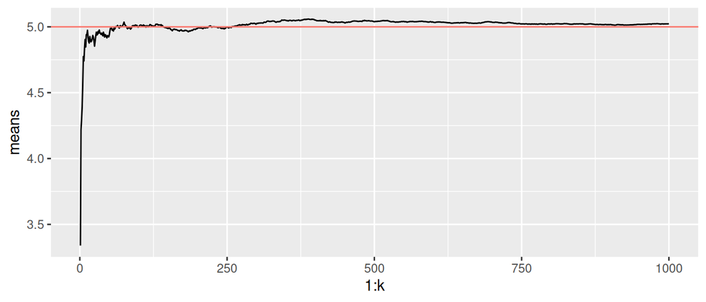

Normalization moves the values so that that $\mu = 0$ and $\sigma = 1$, the standard normal:

$$X = \frac{X' - \mu}{\sigma/\sqrt{n}}.$$

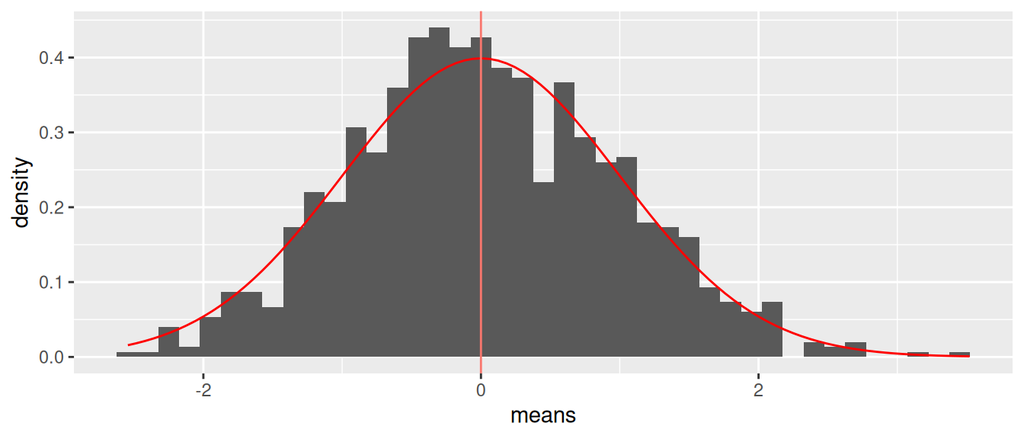

- next: Statistical distributions
- prev: Statistical basics

Orbits!